# Homework 07

Use either R or Python.

## Question 1: LDA

Let’s start by estimating the components of LDA. From the lecture notes, for each target point $\mathbf{x}_0$, we find the class label $k$ with the largest score

$$\mathbf{x}_0^{\mathsf T}\boldsymbol{\Sigma}^{-1}\boldsymbol{\mu}_k
-\frac12\boldsymbol{\mu}_k^{\mathsf T}\boldsymbol{\Sigma}^{-1}\boldsymbol{\mu}_k
+\log\pi_k.$$

Thus, we need to estimate:

- the prior probabilities $\pi_k$;
- the mean vector (centroid) $\boldsymbol{\mu}_k$ for each class; and
- the pooled covariance matrix $\boldsymbol{\Sigma}$.

Use saheart.csv, the `SAheart` data from `ElemStatLearn`. The two classes are defined by `chd`, the coronary heart disease indicator. Use all nine other variables as numerical predictors, coding `famhist` as 1 for `Absent` and 2 for `Present`. The following code constructs an $n\times9$ predictor matrix $\mathbf{X}$ and an $n$-entry response vector $\mathbf{y}$, where $n$ is the number of observations.

**R**

```r
heart <- read.csv("data/saheart.csv")
heart$famhist <- factor(heart$famhist, levels = c("Absent", "Present"))
X <- data.matrix(heart[, names(heart) != "chd"])
y <- heart$chd
```

**Python**

```python
import pandas as pd

heart = pd.read_csv("data/saheart.csv")
heart["famhist"] = heart["famhist"].map({"Absent": 1, "Present": 2})
X = heart.drop(columns="chd").to_numpy()
y = heart["chd"].to_numpy()
```

1. Calculate the prior probabilities, class means, and pooled covariance matrix from these data. Use the pooled covariance denominator $n-K$ from the lecture, where $K=2$ is the number of classes.

   **Show the workflow**

   ```r
   # Use the provided R code to read the saheart.csv
   heart <- read.csv("data/saheart.csv")
   heart$famhist <- factor(heart$famhist, levels = c("Absent", "Present"))
   X <- data.matrix(heart[, names(heart) != "chd"])
   y <- heart$chd

   # Calculate prior probailities
   # pi_k_hat = # of observations in class k / n
   n <- length(y)
   pi_0_hat <- sum(y == 0) / n
   paste("pi_0_hat: ", pi_0_hat)
   ```

   ```
   [1] "pi_0_hat:  0.653679653679654"
   ```

   **Show the workflow**

   ```r
   pi_1_hat <- sum(y == 1) / n
   paste("pi_1_hat: ", pi_1_hat)
   ```

   ```
   [1] "pi_1_hat:  0.346320346320346"
   ```

   **Show the workflow**

   ```r
   # Calculate class means
   mu0_hat <- colMeans(X[y == 0, ])
   mu0_hat
   ```

   ```
          sbp    tobacco        ldl  adiposity    famhist      typea    obesity
   135.460265   2.634735   4.344238  23.969106   1.317881  52.367550  25.737450
      alcohol        age
    15.931358  38.854305
   ```

   **Show the workflow**

   ```r
   mu1_hat <- colMeans(X[y == 1, ])
   mu1_hat
   ```

   ```
          sbp    tobacco        ldl  adiposity    famhist      typea    obesity
   143.737500   5.524875   5.487938  28.120250   1.600000  54.493750  26.622937
      alcohol        age
    19.145250  50.293750
   ```

   **Show the workflow**

   ```r
   # Calculate pooled covariance matrix (K = 2)
   # 1 = sweeps across rows, 2 = sweeps across columns
   K <- 2
   C0_centered <- sweep(X[y == 0, ], 2, mu0_hat, "-")
   C1_centered <- sweep(X[y == 1, ], 2, mu1_hat, "-")
   Sigma_hat <- (crossprod(C0_centered) + crossprod(C1_centered)) / (n - K)
   Sigma_hat
   ```

   ```
                     sbp    tobacco         ldl  adiposity    famhist        typea
   sbp       405.4347786 14.5851882  4.58124834 49.1643582 0.33698819 -15.58772153
   tobacco    14.5851882 19.2425564  0.76320271  7.5381093 0.01582050  -2.05730592
   ldl         4.5812483  0.7632027  4.00058129  6.0326970 0.09185024   0.34459233
   adiposity  49.1643582  7.5381093  6.03269701 56.7528931 0.43280832  -5.30956633
   famhist     0.3369882  0.0158205  0.09185024  0.4328083 0.22583357   0.08112007
   typea     -15.5877215 -2.0573059  0.34459233 -5.3095663 0.08112007  95.56564291
   obesity    18.9388430  1.8334506  2.66005159 22.7078852 0.18402776   2.64006728
   alcohol    64.4003517 20.5170451 -2.53290675 16.1190253 0.76846885   7.96003164
   age        95.1338895 22.7654113  6.47892049 60.5086715 0.99736251 -20.27833492
                obesity     alcohol         age
   sbp       18.9388430  64.4003517  95.1338895
   tobacco    1.8334506  20.5170451  22.7654113
   ldl        2.6600516  -2.5329068   6.4789205
   adiposity 22.7078852  16.1190253  60.5086715
   famhist    0.1840278   0.7684688   0.9973625
   typea      2.6400673   7.9600316 -20.2783349
   obesity   17.6154236   4.6893563  15.6969995
   alcohol    4.6893563 598.2766133  27.8859413
   age       15.6969995  27.8859413 184.1321373
   ```

2. Use your estimated values to predict the label of each observation in the training data. These are in-sample fitted labels. Provide the confusion matrix, with observed classes in rows and predicted classes in columns. Check that the dimensions of your matrices and vectors match. Calculate the scores yourself for this part.

   **Show the workflow**

   ```r
   # Prediction requires scoring every observation under both class possibilities
   # C0_centered and C1_centered contain only observations that belong to their respective classes
   X0 <- sweep(X, 2, mu0_hat, "-")
   X1 <- sweep(X, 2, mu1_hat, "-")

   # Compare the two fitted log scores
   score0 <- -0.5 * rowSums(X0 * t(solve(Sigma_hat, t(X0)))) + log(pi_0_hat)
   score1 <- -0.5 * rowSums(X1 * t(solve(Sigma_hat, t(X1)))) + log(pi_1_hat)
   decision <- ifelse(score0 >= score1, 0, 1)

   # Form the confusion matrix
   # A confusion matirx counts how many observations in each actual class were assigned to each predicted class
   table(Observed = y, Predicted = decision)
   ```

   ```
           Predicted
   Observed   0   1
          0 258  44
          1  73  87
   ```

3. Perform the same LDA analysis using `MASS::lda` in R or `LinearDiscriminantAnalysis(solver="svd")` in Python, using the same numerical predictors and empirical class priors. Provide the confusion matrix. Do the results match?

   **Show the workflow**

   ```r
   heart_lda <- MASS::lda(chd ~ ., data = heart)
   heart_lda_pred <- predict(heart_lda, newdata = heart)$class
   table(Observed = heart$chd, Predicted = heart_lda_pred)
   ```

   ```
           Predicted
   Observed   0   1
          0 258  44
          1  73  87
   ```

   Yes, the results from parts (b) and (c) match.

## Question 2: QDA and marginal screening

In the lecture, ordinary QDA could not be fitted to the handwritten digit sample because its within-class covariance matrices were singular. Let’s consider selecting fewer variables and see whether this helps. For this question, use the full zip-train.csv.gz as the training data and zip-test.csv.gz as the test data, with all ten digit classes. These are the original `zip.train` and `zip.test` data from `ElemStatLearn`. Each file has no header: the first column is the digit label and the remaining 256 columns are pixel values.

Instead of using all 256 predictors, select the 40 with the largest marginal variances in the training data. Here, marginal variance means the variance of one pixel across all training observations. Use the original pixel values without standardizing them, and retain the same selected predictors in the test data.

Use `MASS::qda` in R or `QuadraticDiscriminantAnalysis(tol=1e-8)` in Python.

**Show the workflow**

```r
# Load the training and testing data
train <- read.csv(gzfile("data/zip-train.csv.gz"), header = FALSE)
test <- read.csv(gzfile("data/zip-test.csv.gz"), header = FALSE)

# Remove the first column because it is only a digit label
X_train <- as.matrix(train[, -1])
X_test <- as.matrix(test[, -1])

# Select 40 predictors with the largest marginal variances in the training data
pixel_var <- apply(X_train, 2, var)
top40 <- order(pixel_var, decreasing = TRUE)[1:40]

X_train_40 <- X_train[, top40, drop = FALSE]
X_test_40 <- X_test[, top40, drop = FALSE]
```

1. Fit QDA using these 40 predictors and report the test confusion matrix, with observed classes in rows and predicted classes in columns. Also report the test misclassification rate.

   **Show the workflow**

   ```r
   # Digit labels are class categories, not numeric measurements
   # Factor tells MASS::qda to treat digit labels as group names rather than numeric values
   y_train <- factor(train[, 1])
   y_test <- factor(test[, 1])

   pixel_qda <- MASS::qda(x = X_train_40, grouping = y_train)
   pixel_qda_pred <- predict(pixel_qda, newdata = X_test_40)$class

   # Report the test confusion matrix
   table(Observed = y_test, Predicted = pixel_qda_pred)
   ```

   ```
           Predicted
   Observed   0   1   2   3   4   5   6   7   8   9
          0 319   0  24   6   2   2   1   0   5   0
          1   0 238   5   0  11   0   7   0   3   0
          2   8   0 168   8   8   3   0   0   3   0
          3   5   0   4 128   0  14   0   0  15   0
          4   0   2  13   1 150   1   0   1   7  25
          5  12   0   3   5   1 131   0   0   6   2
          6   0   0   8   0   1   8 148   0   5   0
          7   1   0   6   1   6   0   0 124   2   7
          8   1   0  10  12   3   2   0   0 137   1
          9   0   0   1   2   7   1   1   4   9 152
   ```

   **Show the workflow**

   ```r
   # Report the test misclassification rate
   paste("Test Misclassification Rate: ", mean(pixel_qda_pred != y_test))
   ```

   ```
   [1] "Test Misclassification Rate:  0.155455904334828"
   ```

2. Does the method work? Why do you think it works or does not work?

   In the test confusion matrix, the diagonal entries represent counts that correctly classified images for each digit, and the non-diagonal entries represent counts for misclassifications. In order words, we want more counts in the diagonal entries and less counts in the non-diagonal entries. The test misclassification rate is about 15.55%, which means QDA classified about 84.5% of test images correctly. This suggest that the QDA method worked as a classifier and made useful predictions, but it still made some errors in classifying digits.
3. Repeat the analysis using the 10 predictors with the largest marginal variances in the training data. How does the test misclassification rate compare with the 40-predictor version? Why do you think this happens?

   **Show the workflow**

   ```r
   # Select 10 predictors with the largest marginal variances in the training data
   top10 <- order(pixel_var, decreasing = TRUE)[1:10]

   X_train_10 <- X_train[, top10, drop = FALSE]
   X_test_10 <- X_test[, top10, drop = FALSE]

   # Fit QDA using 10 predictors
   pixel_qda2 <- MASS::qda(x = X_train_10, grouping = y_train)
   pixel_qda_pred2 <- predict(pixel_qda2, newdata = X_test_10)$class

   # Report the test confusion matrix
   table(Observed = y_test, Predicted = pixel_qda_pred2)
   ```

   ```
           Predicted
   Observed   0   1   2   3   4   5   6   7   8   9
          0 298   0  11   1   1  16  28   4   0   0
          1   0 241  10   0   3   1   1   0   2   6
          2  19   2  95  14  14   3  22  21   5   3
          3   5   0   6 103   3  42   0   0   7   0
          4   1   5  14   0  95   2   4  15  17  47
          5  15   0   6  25   4  96   4   2   8   0
          6  41   0  15   4   0  18  78   7   5   2
          7   4   1   6   0   6   0   1 122   0   7
          8   1   2  11  36  12  11   4   1  74  14
          9   0   2   9   2  20   0   0  16  10 118
   ```

   **Show the workflow**

   ```r
   # Report the test misclassification rate
   paste("Test Misclassification Rate: ", mean(pixel_qda_pred2 != y_test))
   ```

   ```
   [1] "Test Misclassification Rate:  0.342301943198804"
   ```

   The misclassification rate for using 10 predictors is about twice as high as the misclassification rate for using 40 predictors. From Week 7 Lecture: Discriminant Analysis, the cost of QDA’s extra flexibility is “estimating a separate covariance requires enough information **within each class**”. With only 10 predictors, QDA estimates smaller covariance matrices for each class, which could be more stable. However, those 10 pixel predictors may leave out useful information for classifying digits. High variance does not necessarily mean a pixel separates the digit classes well.

   The QDA model with 40 predictors retains more useful information to classify digits. This outweighs the cost of extra estimation variability from fitting larger covariance matrices. Overall, losing information with 10 predictors hurts the model more than the smaller covariance estimates help.

## Question 3: Compare LDA and QDA

In this simulation, we will study how the relative performance of LDA and QDA changes with the true covariance structure. The parameter $\rho$ controls the distribution from which we generate the data; it is not a tuning parameter of LDA or QDA.

Consider a classification problem with two equally likely classes, labeled 1 and 2, and $p=10$ covariates. The first two covariates have the class-conditional distributions

$$\begin{pmatrix}X_1\\X_2\end{pmatrix}\mid Y=1
\sim N_2\left(
\begin{pmatrix}-1\\0\end{pmatrix},
\begin{pmatrix}1&\rho\\\rho&1\end{pmatrix}
\right),$$

$$\begin{pmatrix}X_1\\X_2\end{pmatrix}\mid Y=2
\sim N_2\left(
\begin{pmatrix}1\\0\end{pmatrix},
\begin{pmatrix}1&-\rho\\-\rho&1\end{pmatrix}
\right).$$

In both classes, the remaining eight covariates are independent standard normal variables, independent of the first two. Consider

$$\rho\in\{0,0.2,0.4,0.6,0.8,0.9\}.$$

For each value of $\rho$, generate 100 training observations and 1,000 independent test observations from each class. Fit ordinary LDA and QDA using all 10 covariates and equal class priors. Estimate the class means from the training data, with one pooled covariance matrix for LDA and one full covariance matrix per class for QDA. Set a random seed and report it.

The random seed is 43201.

1. Generate one dataset for each value of $\rho$. Fit both methods and calculate their test misclassification rates. Within each setting, use the same training and test observations for the two methods.

   **Show the workflow**

   ```r
   set.seed(43201)
   rho_values <- c(0, 0.2, 0.4, 0.6, 0.8, 0.9)
   simulations <- vector("list", length(rho_values))

   # Generate 100 training observations and 1000 test observations for each value of rho
   for (i in seq_along(rho_values)){
     rho <- rho_values[i]

     Sigma1 <- matrix(c(1, rho, rho, 1), nrow = 2)
     Sigma2 <- matrix(c(1, -rho, -rho, 1), nrow = 2)

     Class1_train <- cbind(
       MASS::mvrnorm(100, mu = c(-1, 0), Sigma = Sigma1),
       matrix(rnorm(100 * 8), nrow = 100)
     )
     Class2_train <- cbind(
       MASS::mvrnorm(100, mu = c(1, 0), Sigma = Sigma2),
       matrix(rnorm(100 * 8), nrow = 100)
     )

     Class1_test <- cbind(
       MASS::mvrnorm(1000, mu = c(-1, 0), Sigma = Sigma1),
       matrix(rnorm(1000 * 8), nrow = 1000)
     )
     Class2_test <- cbind(
       MASS::mvrnorm(1000, mu = c(1, 0), Sigma = Sigma2),
       matrix(rnorm(1000 * 8), nrow = 1000)
     )

     X_train <- rbind(Class1_train, Class2_train)
     y_train <- factor(c(rep(1, 100), rep(2, 100)))

     X_test <- rbind(Class1_test, Class2_test)
     y_test <- factor(c(rep(1, 1000), rep(2, 1000)))

     simulations[[i]] <- list(
       rho = rho,
       X_train = X_train,
       y_train = y_train,
       X_test = X_test,
       y_test = y_test
     )
   }

   # Fit LDA and QDA for each value of rho
   lda_results <- vector("list", length(simulations))
   qda_results <- vector("list", length(simulations))

   for (i in seq_along(simulations)){
     sim <- simulations[[i]]

     # Fit LDA
     lda_fit <- MASS::lda(
       x = sim$X_train,
       grouping = sim$y_train,
       prior = c(0.5, 0.5)
     )

     lda_pred <- predict(lda_fit, newdata = sim$X_test)$class

     lda_results[[i]] <- list(
       rho = sim$rho,
       confusion = table(Observed = sim$y_test, Predicted = lda_pred),
       test_misclass_rate = mean(lda_pred != sim$y_test)
     )

     # Fit QDA
     qda_fit <- MASS::qda(
       x = sim$X_train,
       grouping = sim$y_train,
       prior = c(0.5, 0.5)
     )

     qda_pred <- predict(qda_fit, newdata = sim$X_test)$class

     qda_results[[i]] <- list(
       rho = sim$rho,
       confusion = table(Observed = sim$y_test, Predicted = qda_pred),
       test_misclass_rate = mean(qda_pred != sim$y_test)
     )
   }

   # Estimate the class means from the training data, with one pooled covariance matrix for LDA and one full covariance matrix per class for QDA.
   X_train1 <- X_train[y_train == "1", , drop = FALSE]
   X_train2 <- X_train[y_train == "2", , drop = FALSE]

   mu1_hat <- colMeans(X_train1)
   mu2_hat <- colMeans(X_train2)

   # Calculate pooled covariance matrix for LDA
   C1_centered <- sweep(X_train1, 2, mu1_hat, "-")
   C2_centered <- sweep(X_train2, 2, mu2_hat, "-")
   Sigma_hat_lda <- (crossprod(C1_centered) + crossprod(C2_centered)) / (nrow(X_train) - 2)

   # Calculate full covariance matrix per class for QDA
   Sigma1_hat_qda <- cov(X_train1)
   Sigma2_hat_qda <- cov(X_train2)

   # Output the test classification rates
   test_misclass_results <- data.frame(
     rho = rho_values,
     LDA_test_error = vapply(lda_results, '[[', numeric(1), "test_misclass_rate"),
     QDA_test_error = vapply(qda_results, '[[', numeric(1), "test_misclass_rate")
   )
   test_misclass_results
   ```

   ```
     rho LDA_test_error QDA_test_error
   1 0.0         0.1690         0.1935
   2 0.2         0.1845         0.2155
   3 0.4         0.1605         0.1810
   4 0.6         0.1555         0.1830
   5 0.8         0.1480         0.1265
   6 0.9         0.1535         0.0955
   ```

2. At each fixed value of $\rho$, repeat the experiment 50 times, generating new training and test observations in each repetition. Plot average test error against $\rho$ in one figure, with one curve for LDA and one for QDA. These curves compare performance across different data-generating distributions.

   **Show the workflow**

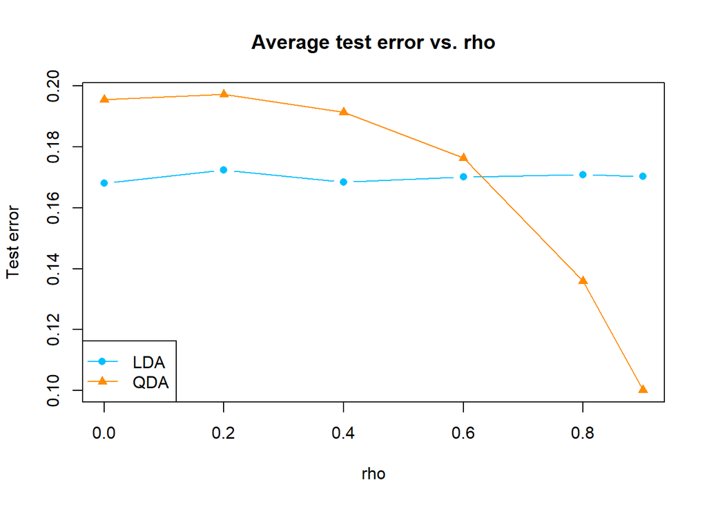

   ```r
   nsim <- 50

   lda_errors <- matrix(NA_real_, nrow = length(rho_values), ncol = nsim)
   qda_errors <- matrix(NA_real_, nrow = length(rho_values), ncol = nsim)

   for (i in seq_along(rho_values)){
     rho <- rho_values[i]

     Sigma1 <- matrix(c(1, rho, rho, 1), nrow = 2)
     Sigma2 <- matrix(c(1, -rho, -rho, 1), nrow = 2)

     for (m in seq_len(nsim)){
       Class1_train <- cbind(
         MASS::mvrnorm(100, mu = c(-1, 0), Sigma = Sigma1),
         matrix(rnorm(100 * 8), nrow = 100)
       )
       Class2_train <- cbind(
         MASS::mvrnorm(100, mu = c(1, 0), Sigma = Sigma2),
         matrix(rnorm(100 * 8), nrow = 100)
       )

       Class1_test <- cbind(
         MASS::mvrnorm(1000, mu = c(-1, 0), Sigma = Sigma1),
         matrix(rnorm(1000 * 8), nrow = 1000)
       )
       Class2_test <- cbind(
         MASS::mvrnorm(1000, mu = c(1, 0), Sigma = Sigma2),
         matrix(rnorm(1000 * 8), nrow = 1000)
       )

       X_train <- rbind(Class1_train, Class2_train)
       y_train <- factor(c(rep(1, 100), rep(2, 100)))

       X_test <- rbind(Class1_test, Class2_test)
       y_test <- factor(c(rep(1, 1000), rep(2, 1000)))

       # Fit LDA and QDA
       lda_fit <- MASS::lda(x = X_train, grouping = y_train, prior = c(0.5, 0.5))
       qda_fit <- MASS::qda(x = X_train, grouping = y_train, prior = c(0.5, 0.5))

       # Calculate test misclassification rate for LDA and QDA
       lda_pred <- predict(lda_fit, newdata = X_test)$class
       qda_pred <- predict(qda_fit, newdata = X_test)$class

       lda_errors[i, m] <- mean(lda_pred != y_test)
       qda_errors[i, m] <- mean(qda_pred != y_test)
     }
   }

   # Plot average test error against rho
   lda_avg <- rowMeans(lda_errors)
   qda_avg <- rowMeans(qda_errors)

   plot(x = rho_values, y = lda_avg,
        main = "Average test error vs. rho",
        xlab = "rho",
        ylab = "Test error",
        ylim = range(lda_avg, qda_avg),
        type = "b",
        pch = 16,
        col = "deepskyblue")

   points(x = rho_values, y = qda_avg,
          pch = 17,
          col = "darkorange")
   lines(x = rho_values, y = qda_avg,
         pch = 17,
         col = "darkorange")

   legend(
     "bottomleft",
     legend = c("LDA", "QDA"),
     col = c("deepskyblue", "darkorange"),
     pch = c(16, 17),
     lty = 1
   )
   ```

3. Compare the two methods at small and large values of $\rho$. How does changing the true covariance structure affect their relative performance? Explain the pattern using their covariance assumptions and the bias-variance trade-off. How can the eight noise covariates affect performance even though they contain no information about the class label?

   At small values of $\rho$, the LDA model generally has a lower average test error than the QDA model. As $\rho$ increases, the average test error for LDA plateaus whereas the average test error for QDA decreases. Eventually, at large values of $\rho$, the QDA model has a lower average test error than the LDA model.

   When $\rho$ is small, the classes’ covariance structures are similar, so LDA’s pooled-covariance assumption is reasonable. LDA estimates fewer parameters, which usually means lower variance than QDA. QDA’s extra flexibility may not help much when the covariance matrices are nearly the same.

   When $\rho$ is large, the classes have different covariance structures. LDA’s pooled-covariance assumption is less accurate, and bias can increase. QDA can model the difference, which reduces the bias. However, QDA estimates more parameters, so it has higher variance. QDA does better when the reduction in bias is larger than the increase in variance.

   The eight noise covariates affect performance even though they contain no information about the class label because the models still have to estimate their means and covariances. Estimating these irrelevant values adds uncertainty, which can make predictions less accurate.

## Question 4: Create and use an LDA/QDA analysis skill

In Homework 5, you created a skill for formatting plots. Now create a reusable skill that guides an AI agent through an LDA/QDA analysis and produces a concise statistical report. You may work with AI to design and write the skill; you do not need to write every line yourself.

1. **Define the skill.** Write a single `SKILL.md` file no larger than **5 KB (5,000 bytes)**. Define the agent’s behavior, analysis guidelines, and expected report structure. Keep the skill independent of this question: provide the dataset, response, and predictors separately when invoking it. The skill may guide the agent to explore lower-dimensional representations, such as principal component analysis (PCA), or to blend the class probabilities predicted by LDA and QDA. Keep all classifiers based on LDA, QDA, or their combination. Configure the skill to load **only when you explicitly invoke it**. Use your AI tool’s invocation settings, or keep the file outside automatically loaded skill folders and supply it only in an explicit request.

Your skill must require a clearly readable analysis report of **at most one printed page**, containing a figure, a table, and numerical model-fitting results. You may specify the type and style of figures and tables you want the AI to produce. All instructions in the skill must be independent of the actual dataset, its variable names, and its observed results. The report should briefly describe the candidate models, the cross-validation procedure and results, the selected model, and its estimated prediction error. It should explain the main findings and any limitations.

2. **Apply the skill.** Explicitly invoke your skill to analyze the `SAheart` data from Question 1, using the same response and predictor coding. Ask the agent to seek the best predictive performance within the LDA/QDA methods allowed by your skill. Include ordinary LDA and QDA as comparisons; the extensions above are optional. Reserve a test set before choosing models. Use the same cross-validation folds within the training data to compare candidates and select any settings. Estimate any preprocessing, including an embedding, using only the training observations in each fold. Refit the selected model and preprocessing on all training observations, then evaluate the fitted classifier once on the reserved test set. Use misclassification rate to compare performance, and report your random seed.
3. **Review and submit.** Check the agent’s analysis and make any skill revisions using only training and cross-validation results. Append the final one-page analysis report and the complete contents of your `SKILL.md` to your homework report. State the file size and briefly explain how you enabled explicit invocation, including the prompt used to apply the skill. The one-page limit applies to the analysis report; the appended skill and this explanation are outside that limit.

Your skill and analysis report will be reviewed and graded by other students through peer evaluation.

### Final one-page analysis report

**SAheart data and procedure.** The analysis used all 462 observations and 9 numerical predictors, coding `famhist` as 1 for Absent and 2 for Present. The random seed was `43207`. A class-stratified 20% holdout reserved 92 observations for final evaluation and left 370 for training. Ordinary LDA (one pooled covariance matrix) and QDA (one covariance matrix per class), both with empirical class priors, were compared using the same stratified 5-fold cross-validation partitions within the training split. Model selection used mean fold misclassification rate only.

| Candidate | Mean 5-fold CV error | Selection |
| --- | --- | --- |
| LDA | 0.2729 | Selected |
| QDA | 0.2920 |  |

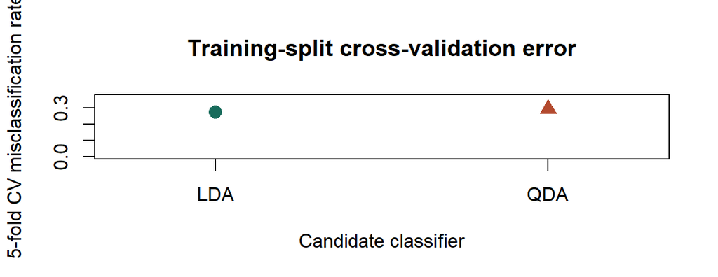

The lowest-CV-error candidate was **LDA** (CV error 0.2729). It was refit using all 370 training observations, then evaluated once on the untouched test split. The held-out test misclassification rate was **0.3043**.

Rows below are observed classes; columns are predicted classes.

Test confusion matrix

|  | Predicted 0 | Predicted 1 |
| --- | --- | --- |
| 0 | 48 | 12 |
| 1 | 16 | 16 |

This single holdout estimate has sampling uncertainty. Both methods assume class-conditional normal predictors; binary `famhist` does not follow a normal distribution, so this assumption is a limitation.

### Skill file details

The complete `SKILL.md` is **4,012 bytes**. It is stored in `LDA-QDA-analysis`, outside the automatically discovered skill folders. Its frontmatter sets `user-invocable: true` and `disable-model-invocation: true`; I supplied it only after explicitly requesting it. The prompt used was: **“Use LDA-QDA-analysis skill to analyze SAheart data from Question 1.”**

### Complete `SKILL.md`

```markdown
---
name: lda-qda-analysis
description: "Use only when explicitly invoked to compare LDA/QDA classifiers, select a model with cross-validation, evaluate it once on a reserved test set, and write a concise statistical report."
user-invocable: true
disable-model-invocation: true
---

# LDA/QDA Analysis

Use this workflow only when the user explicitly invokes this skill and supplies the dataset, response, and predictors. Do not assume variable names, class count, coding, or results. Ask for missing inputs before analysis. Use only LDA, QDA, or combinations of their predicted class probabilities as classifiers.

## Analysis procedure

1.  Identify the response, predictors, class labels, and any required coding. Check for missing/non-numeric predictors, class counts, and whether each class has enough training observations to estimate full covariance matrices. State problems and limitations rather than silently changing the data.
2.  Set and report a random seed. Split off a test set before comparing or selecting models; stratify by class where practical. Do not inspect test labels or use test performance to select features, preprocessing, model settings, or the final model.
3.  Always include ordinary LDA and ordinary QDA as candidates. Additional candidates may use a lower-dimensional representation (such as PCA followed by LDA/QDA) or blend LDA/QDA class probabilities. Keep every classifier within those methods. State each candidate and its settings clearly.
4.  Compare candidates using the same cross-validation folds on the training split and misclassification rate as the selection metric. Choose folds and settings appropriate to the class counts. Fit all preprocessing, feature selection, and embeddings separately within each fold using only that fold's analysis portion; apply the fitted transformation to its validation portion. Do not let validation or test observations influence preprocessing estimates.
5.  Select the candidate with the lowest mean cross-validated misclassification rate. Report fold count, candidate CV errors, selection rule, and any ties or instability. Do not use the reserved test set to revise this choice.
6.  Refit the chosen model and all its preprocessing on the full training split. Evaluate it exactly once on the reserved test split. Report the test confusion matrix (observed rows, predicted columns) and test misclassification rate as the final estimated prediction error. Clearly distinguish CV selection results from this held-out estimate.
7.  Verify that labels, factor/class order, dimensions, confusion-matrix orientation, and error denominators are correct. Do not claim a method works solely because fitting completed or report invented results. If execution is unavailable, provide reproducible code and mark results as not computed.

## Report requirements

Create the analysis report as a Quarto `.qmd` file, following the structure and conventions of the user's homework `.qmd` files. Configure it to render as `.html`, run the document, and verify that the rendered HTML is current and opens successfully.

Produce a clearly readable analysis report that fits on at most one printed page. Include:

- a compact table of candidate methods, their CV misclassification rates, and the selected model;
- one clearly labelled figure comparing candidate CV errors (or another informative, training/CV-only comparison);
- numerical model-fitting results, including sample sizes, seed, selected settings, CV error, and the once-only test error;
- a brief description of candidates and CV procedure, the selection, main findings, and limitations.

Keep the report concise; place code, detailed diagnostics, and the complete skill text outside the one-page report. Do not leak test-set information into the figure or model-selection discussion. Use accessible labels and distinguishable plot series. State when estimates are uncertain, covariance estimation is unstable, or model assumptions may be unsuitable.
```